```python
from bpe import BPE
import matplotlib.pyplot as plt
from wp import WordPiece
```

# `Byte Pair Encoding`

The byte pair tokenization began to get a little healthy, so I created a class to house everything (`bpe.py`)

Due to the extensive execution time, I extended the functionality of my `BPE` class to *save* and *load* the **vocabulary** and **merge rules**.

I've included the folder `bpe` with this submission. There the **vocabulary** and **merge rules** are saved as JSONs.

There's also a `requirements.txt` for `tokenizers`. You'll need that for `WorPiece`.

The Byte-Pair Encoder is built entirely from scratch.

I used a little bit `RegEx` syntax for normalization and pretokenization, and after that it's all hard grinded out code.

Honestly it was pretty rough. Especially with the training times taking so long, which is why this assignment was so late.

By the time I got to part two of this assignment, I didn't have it in me to build **ANOTHER** tokenizer and encoder from scratch.

I imported a tokenizer, and had my own `WordPiece` class inherit it. Then I extended the functionality as needed for this assignment.

#### **`Initialize Byte-Pair Encoder`**

```python
bpe = BPE('BPE-data.txt', rlines = 4000)
```

#### **`Pretrained Byte-Pair Encoding`**

uncomment this to use this byte-pair encoders already pretrained values

```python
# bpe.pretrained()
```

#### **`Train Byte-Pair Encoding`**

uncomment this for a freshly trained bpe

```python
# bpe.train(min_freq = 2)
# bpe.save()
```

## Q1.1: Scatterplot (30 pts: 10 pts for code, 10 pts for each answer)

Please produce a scatterplot showing points `(x, y)`, each corresponding to an iteration of the algorithm, with `x` the current size of the type vocabulary (including the base vocabulary), and `y` the length of the training corpus (in tokens) under that vocabulary’s types.

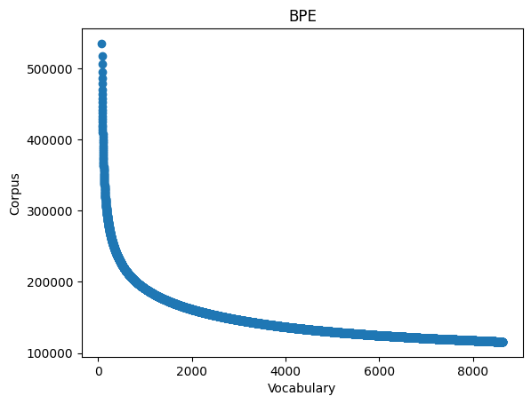

```python
plt.scatter(bpe.x, bpe.y)
plt.xlabel('Vocabulary')
plt.ylabel('Corpus')
plt.title('BPE')
plt.show()
```

```python
print("Initial corpus:", len(bpe.corpus_txt))
print("Vocab size:", len(bpe.vocab))
print("Tokenized corpus:", len(bpe.corpus))
```

```
Initial corpus: 521642
Vocab size: 8636
Tokenized corpus: 100554
```

## Q1.2: Rare word issue (10 pts)

Another way of overcoming the rare word issue is to encode text as a sequence of characters. Discuss the advantages and potential issues of character-level encoding compared to BPE.

**Advantages**  
more intutive and Human readable than bytes  
Less complex for type management with bytes and/or strings  
Any word, unseen or rare, can be generalized

**Disadvantages**  
larger vocabularies  
only useful for specific languages it was trained in  
more resource intensive because each character is tokenized instead of words/subwords  
during inference and training time, this would slow the process compared to byte level

*Byte Level can also read emojis* 🤗

## Q1.3: Evaluate on test data (10 pts)

- Applying your tokenizer on the last 1000 lines of the data, how many tokens do you end up with?
- Do you encounter issues with words that didn’t appear in the training set?
- More generally, when would you expect your tokenizer to fail when applying to an unseen text?

#### `TOKENIZE`

```python
tokens = bpe.tokenize('BPE-data.txt', rlines = -1000, pretrained = True)
```

```python
import sys
kb_b, kb_a = sys.getsizeof(bpe.flattened) / 1024, sys.getsizeof(bpe.to_flattened) / 1024
tkn_b, tkn_a = sum(len(word) for word in bpe.char_level), sum(len(word) for word in bpe.corpus)
kb_comp = ((kb_b - kb_a) / kb_b) * 100
tkn_comp = ((tkn_b - tkn_a) / tkn_b) * 100

print(f'TOKENS BEFORE: {tkn_b:,}')
print(f'(~{kb_b:.0f} KB)')
print(f'"{bpe.flattened[:230]}..."')
print(f'\nTOKENS AFTER: {tkn_a:,}')
print(f'(~{kb_a:.0f} KB)')
print(f'"{bpe.to_flattened[:230]}..."')
print(f"\nBYTES COMPRESSION: {kb_comp:.2f}%")
print(f"TOKEN COMPRESSION: {tkn_comp:.2f}%")
```

```
TOKENS BEFORE: 126,700
(~341 KB)
"W h e n _eow_ o u r _eow_ b r a i n _eow_ r u n s _eow_ h o t _eow_ W h e t h e r _eow_ t h e s e _eow_ i l l u s i o n s _eow_ a r e _eow_ p e r c e i v e d _eow_ t o _eow_ b e _eow_ p l e a s a n t _eow_ o r _eow_ u n p l e a s ..."

TOKENS AFTER: 30,957
(~248 KB)
"When_eow_ our_eow_ brain_eow_ runs_eow_ h ot_eow_ W he ther_eow_ these_eow_ illu sions_eow_ are_eow_ perceived_eow_ to_eow_ be_eow_ pl eas ant_eow_ or_eow_ un pl eas ant_eow_ is_eow_ often_eow_ only_eow_ a_eow_ matter_eow_ of_eow_..."

BYTES COMPRESSION: 27.40%
TOKEN COMPRESSION: 75.57%
```

**TOKENS**  
30,957  
**ISSUES**  
There are a few tokens in the sample output that are a bit akward: 'W he ther_eow_' and 'un pl eas ant_eow_'.  
In my initial BPE training, I didn't normalize case, so 'W he ther_eow_' is akwardly tokenized because of the capital 'w', because 'whether' **is** in the rules.  
I used `<ctrl> + f` in the merge rules json to lookup these tokens, and 'whether' is there (with a lowercase 'w'), but 'unpleasant' doesn't exist at all.  
**UNSEEN TEXT**  
Out of vocabulary (OOV) words are going to be tokenized into incorrectly fragmented subwords, or not tokenized at all.  
This is probably wouldn't allow BPE to generalize very well; for example different slang terms from different areas of the US alone could be missed or improperly handled.

# 2. WordPiece (50 pts)

Now implement WordPiece algorithm on the training set in the previous problem, `BPE-data.txt`.

**Update: Run the algorithm until 4000 new merge rules are learned. (i.e., the vocabulary has size 4000 excluding the base vocabulary)**

```python
# Initialize and train
wp = WordPiece("BPE-data.txt", vocab_size = 4000)
wp.train(iter = True, chunks = 250)
wp.save()
```

## Q2.1: Scatterplot (20 pts: 10 pts for code, 10 pts for answers)

Please produce a scatterplot showing points `(x, y)`, each corresponding to an iteration of the algorithm, with `x` the current size of the type vocabulary (including the base vocabulary), and `y` the length of the training corpus (in tokens) under that vocabulary’s types.

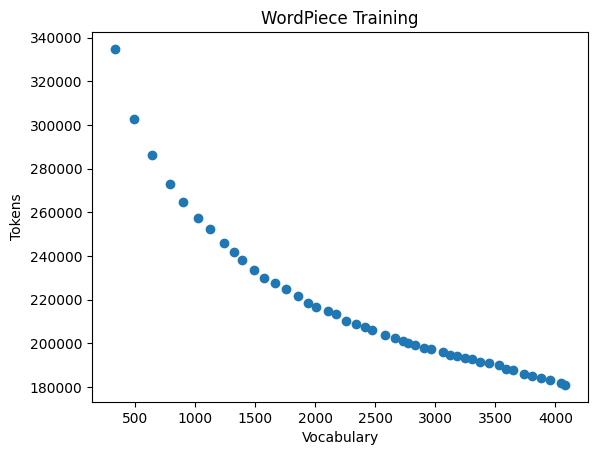

```python
import matplotlib.pyplot as plt

plt.scatter(wp.x, wp.y)
plt.xlabel("Vocabulary")
plt.ylabel("Tokens")
plt.title("WordPiece Training")
plt.show()
```

How many types do you end up with?

What is the length of the training data under your final type vocabulary?

```python
print(f'TYPES: {wp.x[-1]:,}')
print(f'LENGTH: {wp.y[-1]:,}')
```

```
TYPES: 4,084
LENGTH: 180,919
```

## Q2.2: Evaluate on test data (10 pts)

- Applying your tokenizer on the last 1000 lines of the data, report the length of the tokenized data. Also, include the tokenized sequences for the following two sentences:
  - `Analysts were expecting the opposite, a deepening of the deficit.`
  - `Five minutes later, a second person arrived, aged around thirty, with knife wounds.`

```python
tokens = sum(len(token) for token in wp.tokenize('BPE-data.txt', rlines = -1000))
print(f'LENGTH: {tokens:,}')
```

```
LENGTH: 126,692
```

```python
corpus = [
    "Analysts were expecting the opposite, a deepening of the deficit.",
    "Five minutes later, a second person arrived, aged around thirty, with knife wounds."
]

tokens = [wp.tokenize(words) for words in corpus]
for t, words in enumerate(corpus):
    print(f'ORIGINAL: "{words}"')
    print(f'TOKENIZED: "{" ".join(tokens[t])}"\n')
```

```
ORIGINAL: "Analysts were expecting the opposite, a deepening of the deficit."
TOKENIZED: "An ##aly ##st ##s were expect ##ing the opp ##os ##ite , a deep ##en ##ing of the def ##icit ."

ORIGINAL: "Five minutes later, a second person arrived, aged around thirty, with knife wounds."
TOKENIZED: "F ##ive minutes later , a second person arriv ##ed , aged around thirt ##y , with kn ##ife w ##ounds ."
```

## Q2.3 WordPiece vs. BPE (10 pts)

In terms of efficiency and performance, what are the advantages and disadvantages of WordPiece compared with BPE? There is no single correct answer here, just provide your thoughts and rationales, supported by empirical evidence.

Well, as far as speed and efficiency goes, I'm not *entirely* sure since my `bpe` model takes almost 10 minutes to compile, and `wp` only take seconds.

Theoretically though, I'm sure it's safe to say that in a vacuum, `bpe` is going to be much slower, during inference and training. For two reasons: - It starts with character-level tokens and builds from there, while `wp` starts at the *longest* match first. - `bpe` iterates through the entire corpus for merges, and `wp` has a longest [sub]string lookup based on co-occurence probabilities.

But I think *because* `bpe` builds sequentially from the character-level, it's going to be able to generalize a lot better. `ws` matches words and subwords, so (depending on the training sets) `ws` won't be equipped to generalize unseen words.

The tldr is `wp` is less resource intensive and faster. `bpe` is more resource intensive and slower, but it can adapt with OOV words more effectively than `ws`.

But there is a very sharp drop off with the corpus size as the vocab grows with `bpe`. Drastically more so compared to `bpe`.